# 16.1_binary_classification

### Click Here for informatioin on Classification - Logistic Regression Algorithm

```python
import pandas as pd
import numpy as np
import matplotlib.pyplot as plt
% matplotlib inline
from sklearn.base import BaseEstimator, TransformerMixin
from sklearn.pipeline import Pipeline
from sklearn.preprocessing import MinMaxScaler
from sklearn.model_selection import GridSearchCV

plt.rcParams['axes.labelsize'] = 14
plt.rcParams['xtick.labelsize'] = 12
plt.rcParams['ytick.labelsize'] = 12
import warnings
warnings.filterwarnings('ignore')

import random
random.seed(10)
```

```python
digit_dataset = pd.read_csv('../data/digit_recognizer_train.csv')
```

```python
digit_dataset.shape
```

```
(42000, 785)
```

```python
digit_dataset.head()
```

|  | label | pixel0 | pixel1 | pixel2 | pixel3 | pixel4 | pixel5 | pixel6 | pixel7 | pixel8 | ... | pixel774 | pixel775 | pixel776 | pixel777 | pixel778 | pixel779 | pixel780 | pixel781 | pixel782 | pixel783 |
| --- | --- | --- | --- | --- | --- | --- | --- | --- | --- | --- | --- | --- | --- | --- | --- | --- | --- | --- | --- | --- | --- |
| 0 | 1 | 0 | 0 | 0 | 0 | 0 | 0 | 0 | 0 | 0 | ... | 0 | 0 | 0 | 0 | 0 | 0 | 0 | 0 | 0 | 0 |
| 1 | 0 | 0 | 0 | 0 | 0 | 0 | 0 | 0 | 0 | 0 | ... | 0 | 0 | 0 | 0 | 0 | 0 | 0 | 0 | 0 | 0 |
| 2 | 1 | 0 | 0 | 0 | 0 | 0 | 0 | 0 | 0 | 0 | ... | 0 | 0 | 0 | 0 | 0 | 0 | 0 | 0 | 0 | 0 |
| 3 | 4 | 0 | 0 | 0 | 0 | 0 | 0 | 0 | 0 | 0 | ... | 0 | 0 | 0 | 0 | 0 | 0 | 0 | 0 | 0 | 0 |
| 4 | 0 | 0 | 0 | 0 | 0 | 0 | 0 | 0 | 0 | 0 | ... | 0 | 0 | 0 | 0 | 0 | 0 | 0 | 0 | 0 | 0 |

5 rows × 785 columns

```python
digit_X = digit_dataset.iloc[:, 1:]
digit_y = digit_dataset['label']
```

```python
# By default train_test_split does STRATIFIED split based on label (y-value).
from sklearn.model_selection import train_test_split
digit_X_train, digit_X_test, digit_y_train, digit_y_test = train_test_split(digit_X, digit_y, test_size=0.2)
```

```python
# 80% of housing_data.shape[0] = 1168
# def custom_train_test_split(data_set, test_size = 0.2):
#     max_index = data_set.shape[0] - 1
#     train_size = max_index*(1 - test_size)
#     train_indexs = np.linspace(start=0, stop=max_index, num=train_size, dtype=int)
#     test_indexs = [x for x in range(max_index) if x not in train_indexs]
#     print(len(train_indexs))
#     print(len(test_indexs))
#     train_set = data_set.loc[train_indexs]
#     test_set = data_set.loc[test_indexs]
#     return train_set, test_set

# digit_train_set, digit_test_set = custom_train_test_split(digit_dataset)
# digit_X_train = digit_train_set.iloc[:, 1:]
# digit_y_train = digit_train_set['label']
# digit_X_test = digit_test_set.iloc[:, 1:]
# digit_y_test = digit_test_set['label']
```

```python
digit_X_train.shape
```

```
(33600, 784)
```

```python
some_digit = digit_X_train.iloc[6635]
some_digit_image = some_digit.reshape(28, 28)
```

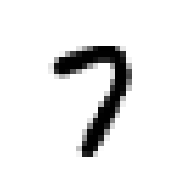

```python
from  matplotlib.cm import  binary
#plt.figure(figsize=(10,10))
plt.imshow(some_digit_image, cmap = binary,
           interpolation="nearest")
plt.axis("off")
plt.show()
```

```python
digit_y_train.iloc[6635]
```

```
7
```

### Binary Classifier

Let’s simplify the problem, we will classify if a row represents "5" or not. This is called binary classifier (just two calsses "5" and "not-5"). Let’s create the target vectors for this classification task

```python
digit_y_train_lbl = (digit_y_train == 5)
digit_y_test_lbl = (digit_y_test == 5)
```

```python
digit_y_train_lbl[:10]
```

```
7697     False
26349    False
6986     False
9937     False
14537    False
24622    False
2628     False
37795    False
27144    False
7335     False
Name: label, dtype: bool
```

```python
type(digit_y_test_lbl)
```

```
pandas.core.series.Series
```

```python
digit_y_train_lbl.head()
```

```
7697     False
26349    False
6986     False
9937     False
14537    False
Name: label, dtype: bool
```

```python
pipeline_min_max_scale = Pipeline([
    ('minMaxScaler', MinMaxScaler())
])
```

```python
digit_X_train = pipeline_min_max_scale.fit_transform(digit_X_train)
```

```python
from sklearn.linear_model import SGDClassifier

sgd_clf = SGDClassifier(random_state=42)
sgd_clf.fit(digit_X_train, digit_y_train_lbl)
```

```
SGDClassifier(alpha=0.0001, average=False, class_weight=None, epsilon=0.1,
       eta0=0.0, fit_intercept=True, l1_ratio=0.15,
       learning_rate='optimal', loss='hinge', n_iter=5, n_jobs=1,
       penalty='l2', power_t=0.5, random_state=42, shuffle=True, verbose=0,
       warm_start=False)
```

### Measure accuracy using corss_val_score

- scroing can be one of ['accuracy', 'adjusted_rand_score', 'average_precision', 'f1', 'f1_macro', 'f1_micro', 'f1_samples', 'f1_weighted', 'neg_log_loss', 'neg_mean_absolute_error', 'neg_mean_squared_error', 'neg_median_absolute_error', 'precision', 'precision_macro', 'precision_micro', 'precision_samples', 'precision_weighted', 'r2', 'recall', 'recall_macro', 'recall_micro', 'recall_samples', 'recall_weighted', 'roc_auc']
- We are going to take **accuracy** as a first step to understand model performance. **Accuracy** is the **number of sample cases correctly classified** (could be positive or negetive) out of **total number of sample cases.**

```python
from sklearn.model_selection import cross_val_score
cv_accuracy_scors = cross_val_score(sgd_clf, digit_X_train, digit_y_train_lbl, cv=3, scoring="accuracy")
print("Accuracy Scores : ", cv_accuracy_scors)
print("Average Accuracy Scores : ", cv_accuracy_scors.mean())
```

```
Accuracy Scores :  [ 0.96544643  0.96098214  0.94883929]
Average Accuracy Scores :  0.958422619048
```

#### Accuracy manual calculation - TEST set (we shouldn't touch test set until we are confident that the model will work fine)

```python
digit_X_test = pipeline_min_max_scale.transform(digit_X_test)
```

```python
digit_pred_y = sgd_clf.predict(digit_X_test)
total_pred = digit_pred_y.shape[0]
correct_pred = digit_pred_y[digit_y_test_lbl == digit_pred_y].shape[0]
accuracy = correct_pred/total_pred
print(accuracy)
```

```
0.9605952380952381
```

#### Accuracy using accuracy_score - TEST set

```python
from sklearn.metrics import accuracy_score
accu_score = accuracy_score(digit_y_test_lbl, digit_pred_y)
print(accu_score)
```

```
0.960595238095
```

### This looks good we have got 0.95 on TRAIN, 0.96 on TEST set, Is accuracy a good measure ? : let's check

- Let's define a dumb classifier that classifies all records as not "not-5"

```python
from sklearn.base import BaseEstimator
class Not5Classifier(BaseEstimator):
    def fit(self, X, y=None):
        pass
    def predict(self, X):
        return np.zeros((len(X), 1), dtype=bool)
```

```python
not5_clf = Not5Classifier()
cross_val_score(not5_clf, digit_X_train, digit_y_train_lbl, cv=3, scoring="accuracy")
```

```
array([ 0.91107143,  0.91053571,  0.90866071])
```

With dumb classifier, we have got around 90% accuracy, this happened because about 90% of the train set are not 5's. This concludes that **accuracy is not a good measure for skewed datasets.**

# Classification Model performace measures

#### 1. Confusion matrix

- The basic idea is to know how many times Class - A is "classified A" and "not as A". There could be more than 2 classes.
- To generate confusion matrix we need cross validated predictions (not scores as we got in cross_val_score method) as we are not going to touch TEST set now.

```python
from sklearn.model_selection import cross_val_predict
pred_y_train = cross_val_predict(sgd_clf, digit_X_train, digit_y_train_lbl, cv=5)
```

```python
pred_y_train.shape
```

```
(33600,)
```

```python
from sklearn.metrics import confusion_matrix
con_mat = confusion_matrix(digit_y_train_lbl, pred_y_train)
print(con_mat)
```

```
[[30018   561]
 [  625  2396]]
```

[figure not shown]

#### Recall is also called as "Sensitivity" or "True Positive Rate (TPR)"

```python
from sklearn.metrics import precision_score, recall_score
prec_score = precision_score(digit_y_train_lbl, pred_y_train)
print("Precision Score : ", prec_score)
rec_score = recall_score(digit_y_train_lbl, pred_y_train)
print("Recall Score", rec_score)
```

```
Precision Score :  0.810280689888
Recall Score 0.793114862628
```

### F1 - Score:

- F1-Score is a combination of Precision and Recall. F1-Score is a harmonic mean of precision and recall (harmonic mean gives more weight to low value). As a result, the classifier will give high F1-Score only if both Precision and Recall are high. \begin{equation*} F1 = \frac{2} {\frac{1} {Precision} + \frac{1} {Recall}} = \frac{TP} {TP + \frac{FN + FP} {2}} \end{equation*}
- F1-Score is a simple way to compare two classifiers.

```python
from sklearn.metrics import f1_score
f1_score(digit_y_train_lbl, pred_y_train)
```

```
0.80160588825694212
```

- F1-Score favors classifiers that have similar Precision and Recall. This is not always what we want, in some cases high Precision is prefered, in other cases high Recall is prefered
- Example "High Precision" prefered case : Healthy Food classifier should have High Precision (Healthy food classification should be correct(High Precision), It is fine to miss-classify some healty food as unhealthy(Low Recall)
- Example "High Recall" prefered case : Heart Attach probability calssifier should have High Recall (have to classify all future Heart Attack patient correctly(High Recall), may incorrectly predict some as future Heart Attack patients).

### Precision-Recall Trade Off : Increasing Precision reduces Recall, and vice versa. This is called as precision-recall trade off

- Scikit-Learn provides a way to take controle over Precision, Recall scores. We can use method=decision_function in cross_val_predict and get decision scores. Try different thresholds (a number) to find different Precision, Recall scores and settle at a satisfying threshold.

[figure not shown]

- An easier way to find best threshold for desired Precision or Recall is to plot graph between Precision/Recall VS Threshold (precision_recall_curve).

```python
y_decision_score = cross_val_predict(sgd_clf, digit_X_train, digit_y_train_lbl, method='decision_function', cv=5)
```

```python
from sklearn.metrics import precision_recall_curve
precisions, recalls, thresholds = precision_recall_curve(digit_y_train_lbl, y_decision_score)
```

```python
print(precisions.shape)
print(recalls.shape)
print(thresholds.shape)
```

```
(33111,)
(33111,)
(33110,)
```

```python
thresholds.max()
```

```
28.748126870794167
```

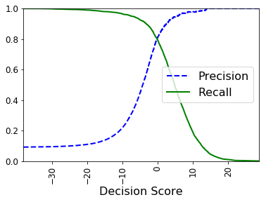

```python
plt.plot(thresholds, precisions[:-1], "b--", label="Precision", linewidth=2)
plt.plot(thresholds, recalls[:-1], "g-", label="Recall", linewidth=2)
plt.xlabel("Decision Score", fontsize=16)
plt.legend(loc="center right", fontsize=16)
plt.xlim([np.min(thresholds), np.max(thresholds)])
plt.ylim([0, 1])
plt.xticks(rotation=90)
```

#### Can we guess SGDClassifier's threshold ?

#### What if we change threashold to 20?

#### How can we define a classifier with 90% precision ?

```python
pred_y_train = (y_decision_score > 0)
```

```python
pred_y_train[:20]
```

```
array([False, False, False, False, False, False, False, False, False,
       False,  True, False, False, False, False, False, False, False,
       False, False], dtype=bool)
```

```python
prec_score = precision_score(digit_y_train_lbl, pred_y_train)
print("Precision Score : ", prec_score)
rec_score = recall_score(digit_y_train_lbl, pred_y_train)
print("Recall Score", rec_score)
```

```
Precision Score :  0.810280689888
Recall Score 0.793114862628
```

### Precision - Recall Curve

```
[0, 1, 0, 1]
```

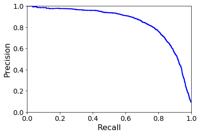

```python
plt.rcParams['xtick.labelsize'] = 14
plt.rcParams['ytick.labelsize'] = 14
plt.plot(recalls, precisions, "b-", linewidth=2)
plt.xlabel("Recall", fontsize=16)
plt.ylabel("Precision", fontsize=16)
plt.axis([0, 1, 0, 1])
```

#### To find decision score of some independent variable

```python
sgd_clf.decision_function(some_digit)
```

```
array([-1567.49983739])
```

### ROC (Receiver Operating Characteristic) Curve: The plot between TRUE POSITIVE RATE (recall/sensitivity) and FALSE POSITIVE RATE (1 - true negetive rate). (True Negetive Rate is also known as "Specificity")

- TRUE POSITIVE RATE (TPR or Sensitivity or Recall) = $\frac{TP} {TP + FN} $
- FALSE POSITIVE RATE (FPR) = $\frac{FP} {FP + TN} $
- TRUE NEGETIVE RATE (TNR or Specificity) = $\frac{TN} {TN + FP} $
- This curve is commonly used with binary classifier.

```python
import matplotlib.pyplot as plt
import matplotlib.image as mpimg
from sklearn.metrics import roc_curve

fpr, tpr, thresholds = roc_curve(digit_y_train_lbl, y_decision_score)
```

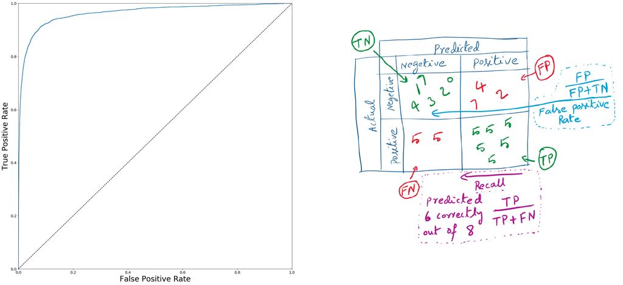

```python
plt.figure(figsize=(40,40))
plt.subplot(2,2,1)

plt.rcParams['xtick.labelsize'] = 26
plt.rcParams['ytick.labelsize'] = 26
plt.plot(fpr, tpr, linewidth=2)
plt.plot([0, 1], [0, 1], 'k--')
plt.axis([0, 1, 0, 1])
plt.xlabel('False Positive Rate', fontsize=28)
plt.ylabel('True Positive Rate', fontsize=28)
plt.subplot(2,2,2)
plt.imshow(mpimg.imread('ROC_related_formulas.png'))
plt.axis("off")
plt.show()
```

### Area Under the Curve: The area under the ROC curve is called AUC score. A perfect classifier will have AUC score of "1". A purly random classifier will have AUC score of "0.5"

```python
from sklearn.metrics import roc_auc_score

roc_auc_score(digit_y_train_lbl, y_decision_score)
```

```
0.96415570312780197
```

- ROC curve is so similar to the Precision-Recall curve, you may wonder how to decide which one to use. As a rule of thumb, you should prefer the Precision-Recall curve whenever the positive class is rare (as in the digit recognizer dataset) or when you care more about the false positives than the false negatives, and the ROC curve otherwise.
- Precision-Recall curve shows that there is lot of scope for imporvement.